# Reproducible Research - Peer Assessment 1

November 12, 2015

## Introduction

It is now possible to collect a large amount of data about personal movement using activity monitoring devices such as a Fitbit, Nike Fuelband, or Jawbone Up. These type of devices are part of the “quantified self” movement - a group of enthusiasts who take measurements about themselves regularly to improve their health, to find patterns in their behavior, or because they are tech geeks. But these data remain under-utilized both because the raw data are hard to obtain and there is a lack of statistical methods and software for processing and interpreting the data.

This assignment makes use of data from a personal activity monitoring device. This device collects data at 5 minute intervals through out the day. The data consists of two months of data from an anonymous individual collected during the months of October and November, 2012 and include the number of steps taken in 5 minute intervals each day.

## Loading and Preprocessing the Data

```r
activity<-read.csv("activity.csv")
str(activity)
```

```
## 'data.frame':    17568 obs. of  3 variables:
##  $ steps   : int  NA NA NA NA NA NA NA NA NA NA ...
##  $ date    : Factor w/ 61 levels "2012-10-01","2012-10-02",..: 1 1 1 1 1 1 1 1 1 1 ...
##  $ interval: int  0 5 10 15 20 25 30 35 40 45 ...
```

```r
activity["date"]<-as.Date(activity$date,"%Y-%m-%d")
```

## What is mean total number of steps taken per day?

Calculating the total number of steps taken per day

```r
total_steps<-aggregate(steps~date, data = activity, sum, na.rm=TRUE)
```

Histogram of the total number of steps taken each day

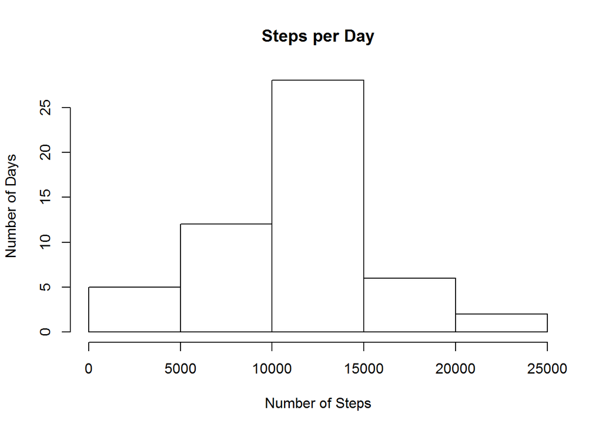

```r
hist(total_steps$steps, xlab="Number of Steps", ylab = "Number of Days",
main = "Steps per Day")
```

The mean and median of the total number of steps taken per day are

```r
mean(total_steps$steps)
```

```
## [1] 10766.19
```

```r
median(total_steps$steps)
```

```
## [1] 10765
```

## What is the average daily activity pattern?

A time series plot of the 5-minute interval and the average number of steps taken, averaged across all days

```r
average_steps<-aggregate(steps~interval, data = activity, mean)
str(average_steps)
```

```
## 'data.frame':    288 obs. of  2 variables:
##  $ interval: int  0 5 10 15 20 25 30 35 40 45 ...
##  $ steps   : num  1.717 0.3396 0.1321 0.1509 0.0755 ...
```

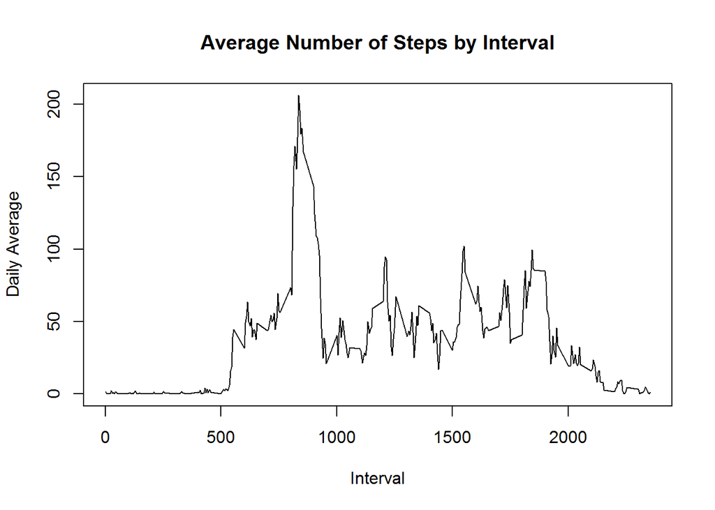

```r
plot(average_steps$interval, average_steps$steps,type="l", xlab="Interval",
ylab = "Daily Average", main = "Average Number of Steps by Interval")
```

5-minute interval that contains the maximum number of steps (on average across all the days in the dataset) is 835

```r
average_steps[which.max(average_steps$steps),"interval"]
```

```
## [1] 835
```